# 260124_ggir_clinics_01 – integrativní report (M0/M6)

### 5.8.6 Váhy proměnných (top weights)

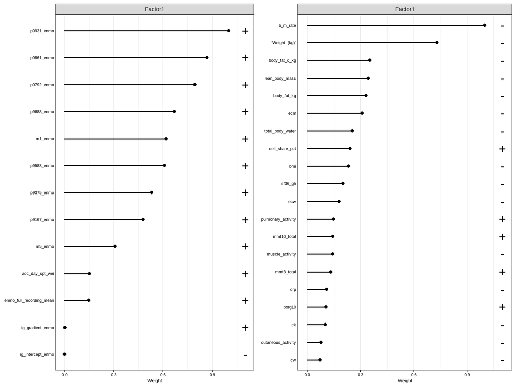

**Co vidíme:** Nejvyšší váhy v aktivitě mají `p9931_enmo, p9861_enmo, p9792_enmo, p9688_enmo, m1_enmo`, v klinice `b_m_rate,`Weight (kg)`, body_fat_c_kg, lean_body_mass, body_fat_kg`.

**Jak to číst:** Proměnné s nejvyšší vahou definují, co faktor biologicky reprezentuje.

**Co to znamená pro myozitidy:** Pokud jsou mezi top váhami funkční skóry (MMT/HAQ/SF‑36) a laboratorní markery, odpovídá to literatuře, která popisuje propojení svalové funkce a klinické aktivity nemoci.

**Co je nejisté:** Váhy jsou citlivé na počet faktorů a škálování vstupních dat.

**Jaký další krok:** Ověřit, zda stejné top váhy vycházejí i při jiném nastavení počtu faktorů.

### 5.8.7 Tabulka: Top váhy (faktor 1)

| Klinika – proměnná | Váha |
| --- | --- |
| b_m_rate | -2.9685242 |
| `Weight (kg)` | -2.1712763 |
| body_fat_c_kg | -1.0502180 |
| lean_body_mass | -1.0220923 |
| body_fat_kg | -0.9847093 |
| ecm | -0.9175113 |
| total_body_water | -0.7502011 |
| cell_share_pct | 0.7132244 |
| bmi | -0.6847140 |
| sf36_gh | -0.5966030 |

**Co vidíme:** Konkrétní proměnné s nejvyšší váhou ve faktoru 1.  
**Jak to číst:** Větší absolutní váha = silnější příspěvek k faktoru.  
**Co to znamená pro myozitidy:** Proměnné mohou fungovat jako biologické ukotvení latentního faktoru.  
**Co je nejisté:** Interpretace se může lišit u dalších faktorů.  
**Jaký další krok:** Provést biologickou anotaci proměnných a ověřit klinický smysl.

## 5.9 MOFA: ČAS (M0/M6)

### 5.9.1 Faktory – rozložení podle subtypu

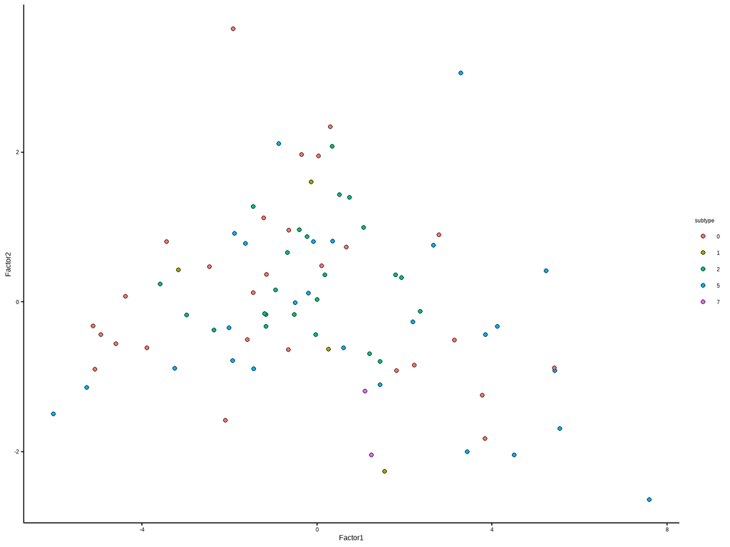

**Co vidíme:** Subtyp 7 má nejvyšší medián Factor1 1.17, Subtyp 0 nejnižší -0.90 (Δ≈2.07).

**Jak to číst:** Rozdíly mezi subtypy na faktorové ose ukazují, že časové metriky nesou fenotypovou informaci.

**Co to znamená pro myozitidy:** Různé subtypy IIM mohou mít odlišný denní režim aktivity a únavy, což je konzistentní s heterogenitou popsanou v literatuře.

**Co je nejisté:** Některé subtypy mohou být málo zastoupené.

**Jaký další krok:** Validovat na větším vzorku a zahrnout více časových ukazatelů.

### 5.9.2 Faktory 3–4 – rozložení podle subtypu

[figure not shown]

**Co vidíme:** Subtyp 1 má nejvyšší medián Factor3 1.12, Subtyp 7 nejnižší -3.54 (Δ≈4.66).

**Jak to číst:** Faktory 3–4 doplňují hlavní osu o jemnější časové profily.

**Co to znamená pro myozitidy:** Sekundární faktory mohou odrážet rozdíly v denním režimu a únavě mezi subtypy, které nejsou zachyceny faktorem 1–2.

**Co je nejisté:** Interpretace vyšších faktorů bývá méně stabilní při malých počtech pacientů.

**Jaký další krok:** Doplnit interpretaci o top váhy pro faktory 3–4 a jejich klinické ukotvení.

### 5.9.3 Faktory – rozložení podle M0/M6

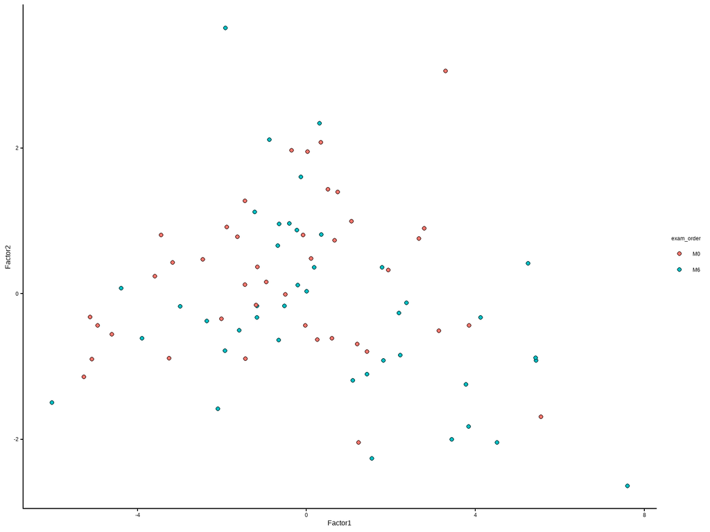

**Co vidíme:** M0 má medián Factor1 -0.22, M6 -0.07 (Δ=0.15). U Factor2 je M0 0.20 a M6 -0.30 (Δ=-0.50).

**Jak to číst:** Posun M0→M6 ukazuje časovou dynamiku latentních faktorů.

**Co to znamená pro myozitidy:** Změna faktorů může odpovídat klinickému zlepšení či zhoršení, což je v souladu s literaturou o dlouhodobém kolísání IIM.

**Co je nejisté:** Časový posun může být ovlivněn léčbou, komorbiditami a denním režimem.

**Jaký další krok:** Porovnat změny faktorů s objektivními klinickými endpointy.

### 5.9.4 Faktory 3–4 – rozložení podle M0/M6

[figure not shown]

**Co vidíme:** M0 má medián Factor3 -0.80, M6 0.14 (Δ=0.93). U Factor4 je M0 -0.16 a M6 -0.11 (Δ=0.04).

**Jak to číst:** Změny sekundárních faktorů mohou zachytit jemné posuny denního rytmu.

**Co to znamená pro myozitidy:** Posun faktorů 3–4 může souviset s únavou nebo adaptací na léčbu, což literatura u IIM často zdůrazňuje.

**Co je nejisté:** Malé posuny mohou být citlivé na parametry MOFA a na chybějící data.

**Jaký další krok:** Porovnat posuny s klinickými změnami a aktigrafickými delta metrikami.

### 5.9.5 UMAP na faktorech

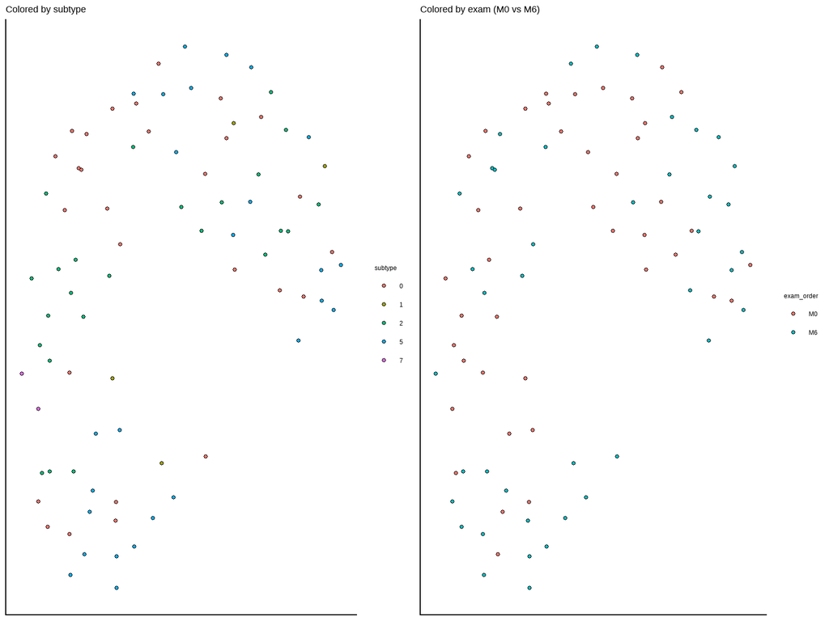

**Co vidíme:** Centroidy M0 a M6 v UMAP prostoru jsou vzdálené ~0.79.

**Jak to číst:** Větší vzdálenost centroidů značí globální posun v časovém profilu mezi M0 a M6.

**Co je nejisté:** UMAP může zvýraznit i slabé struktury a je citlivý na parametry.

**Jaký další krok:** Potvrdit shluky kvantitativně (silhouette, stability) a porovnat s klinickými skóry.

### 5.9.6 Váhy proměnných (top weights)

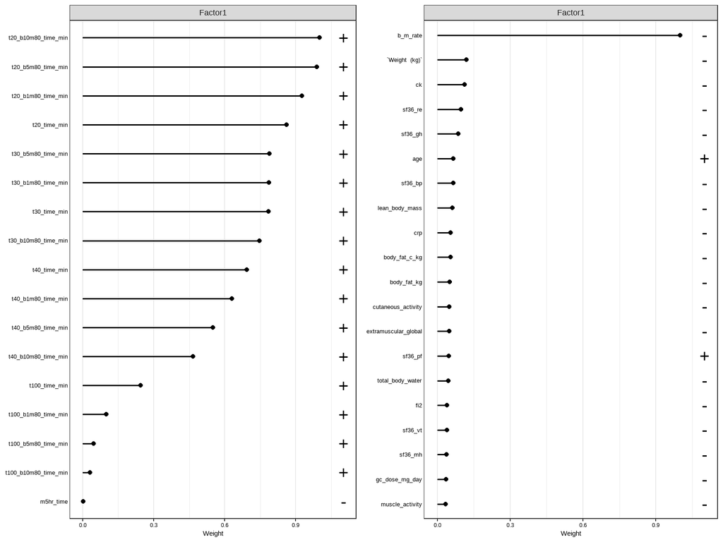

**Co vidíme:** Nejvyšší váhy v časovém bloku mají `t20_b10m80_time_min, t20_b5m80_time_min, t20_b1m80_time_min, t20_time_min, t30_b5m80_time_min`, v klinice `b_m_rate,`Weight (kg)`, ck, sf36_re, sf36_gh`.

**Jak to číst:** Proměnné s nejvyšší vahou definují, které časové aspekty jsou pro faktor klíčové.

**Co to znamená pro myozitidy:** V literatuře se časové metriky aktivity pojí s únavou a funkční kapacitou; proto dává smysl, že se objevují mezi top váhami.

**Co je nejisté:** Váhy mohou být citlivé na počet faktorů a na škálování vstupů.

**Jaký další krok:** Ověřit top váhy při jiném nastavení faktorů a porovnat s klinickým hodnocením.

### 5.9.7 Tabulka: Top váhy (faktor 1)

| Klinika – proměnná | Váha |
| --- | --- |
| b_m_rate | -18.898689 |
| `Weight (kg)` | -2.272749 |
| ck | -2.113993 |
| sf36_re | -1.849970 |
| sf36_gh | -1.615464 |
| age | 1.242718 |
| sf36_bp | -1.241085 |
| lean_body_mass | -1.171036 |
| crp | -1.036815 |
| body_fat_c_kg | -1.013382 |

**Co vidíme:** Konkrétní časové a klinické proměnné s největší vahou ve faktoru 1.  
**Jak to číst:** Vyšší absolutní váha = silnější vazba na faktor.  
**Co to znamená pro myozitidy:** Tyto proměnné mohou být klíčové pro časový fenotyp.  
**Co je nejisté:** Interpretace faktorů bez externího ukotvení může být subjektivní.  
**Jaký další krok:** Spojit faktory s klinickými endpointy (MMT, CK apod.).

# 6 Revmatologické zhodnocení (syntéza napříč metodami)

Metody rCCA, DIABLO i MOFA ukazují na **společné, ale komplementární pohledy** na pacientské fenotypy. rCCA zdůrazňuje **lineární sdílenou variabilitu** mezi aktivitou/časem a klinikou, DIABLO cíleně hledá **diskriminační signatury subtypů**, zatímco MOFA odhaluje **latentní osy** bez dohledu.

Z hlediska myozitid je nejcennější shoda v tom, že **proměnné aktivity a kliniky se systematicky pojí**, což podporuje biologický význam aktigrafických metrik. Pokud se v DIABLO a rCCA opakují podobné proměnné, je to silný kandidát na klinicky relevantní biomarker. MOFA navíc může odhalit faktory, které nejsou přímo popsány stávajícími subtypy, a tím rozšířit fenotypovou stratifikaci.

**Co se shoduje:**  
- Opakované proměnné mezi rCCA a DIABLO naznačují konzistentní signál napříč metodami.  
- U MOFA faktory často zachycují podobné „klinicko‑aktivní“ osy, i bez dohledu.

**Co je specifické:**  
- DIABLO přímo optimalizuje rozlišení subtypů a dává jasnou signaturu.  
- rCCA poskytuje interpretable osu sdílené variability bez nutnosti klasifikace.  
- MOFA umožňuje identifikovat latentní faktory, které mohou být klinicky „skryté“.

**Implikace pro myozitidy:**  
- Podpora pro stratifikaci pacientů kombinující kliniku a objektivní aktivitu.  
- Možnost identifikovat „tichý“ fenotyp s minimálními klinickými projevy, ale změněnou aktivitou.

**Doporučení pro manuskript:**  
- Hlavní text: rCCA (osa klinika‑aktivita) + DIABLO signatura subtypů.  
- Supplement: detailní MOFA faktory a kompletní seznamy proměnných.

**Doporučení pro grantovou zprávu:**  
- Zdůraznit, že aktigrafie přináší nezávislý a klinicky významný signál.  
- Uvést potenciál pro personalizované sledování a stratifikaci pacientů.

# 7 Session info

**Platform**

| Setting | Value |
| --- | --- |
| version | R version 4.5.2 (2025-10-31 ucrt) |
| os | Windows 10 x64 (build 19045) |
| system | x86_64, mingw32 |
| ui | RTerm |
| language | (EN) |
| collate | Czech_Czechia.utf8 |
| ctype | Czech_Czechia.utf8 |
| tz | Europe/Prague |
| date | 2026-01-25 |
| pandoc | 3.6.3 @ F:/R/RStudio/resources/app/bin/quarto/bin/tools/ (via rmarkdown) |
| quarto | NA @ F:.exe |

**Used packages**

| package | loadedversion | date |
| --- | --- | --- |
| conflicted | 1.2.0 | 2023-02-01 |
| dplyr | 1.1.4 | 2023-11-17 |
| forcats | 1.0.1 | 2025-09-25 |
| ggplot2 | 4.0.1 | 2025-11-14 |
| glue | 1.8.0 | 2024-09-30 |
| knitr | 1.51 | 2025-12-20 |
| lattice | 0.22-7 | 2025-04-02 |
| lubridate | 1.9.4 | 2024-12-08 |
| MASS | 7.3-65 | 2025-02-28 |
| mixOmics | 6.32.0 | 2025-04-15 |
| MOFA2 | 1.18.0 | 2025-04-15 |
| purrr | 1.2.1 | 2026-01-09 |
| readr | 2.1.6 | 2025-11-14 |
| rio | 1.2.4 | 2025-09-26 |
| stringr | 1.6.0 | 2025-11-04 |
| tibble | 3.3.0 | 2025-06-08 |
| tidyr | 1.3.2 | 2025-12-19 |
| tidyverse | 2.0.0 | 2023-02-22 |